# Developing Quaternion and Space-time Number Tools for iPython3

```python
suite = unittest.TestLoader().loadTestsFromModule(TestQ8())
unittest.TextTestRunner().run(suite);
```

```
..........................
```

```
abs_of_q: ((5.0, 0), (0, 0), (0, 0), (0, 0)) Q.Q.abs
abs_of_vector: ((5.0, 0), (0, 0), (0, 0), (0, 0)) Q.absV
add: ((1, 0), (4, 2), (0, 6), (0, 4)) Q+Q
add reduce: ((1, 0), (2, 0), (0, 6), (0, 4)) Q+Q.reduce
q1_sq: ((0, 28), (0, 4), (0, 6), (0, 8)) Q.Q_sq.reduce
boosted: ((1.51802716224446, 0.5060090540814867), (1.0030180271622444, 3.0090540814867333), (1.5240542164879485, 4.524054216487949), (2.0180721626494638, 6.018072162649464)) Q.boost
b squared: ((0, 28.000000000000007), (0, 4.06028962520837), (0, 6.072108648977842), (0, 8.096144865303788)) Q.boost.Q.boost_sq.reduce
conj 0: ((1, 0), (2, 0), (3, 0), (4, 0)) Q.*
conj 1: ((0, 1), (0, 2), (3, 0), (4, 0)) Q.*1
conj 2: ((0, 1), (2, 0), (0, 3), (4, 0)) Q.*2
dif: ((1, 0), (0, 6), (3, 3), (0, 4)) Q-Q
inverse: ((1.0, 0.0), (0, 0), (0, 0), (0, 0)) Q/Q.reduce
q1_sq: ((0, 28), (0, 4), (0, 6), (0, 8)) Q.Q_sq.reduce
g_shift: ((0.997004495503373, 0), (0, 2.00600900900675), (0, 3.00901351351013), (0, 4.01201801801351)) Q.g_exp
g squared: ((0, 28.1805050815139), (0, 4.00000000000000), (0, 6.00000000000000), (0, 8.00000000000000)) Q.g_exp.Q.g_exp_sq.reduce
inverse: ((0.0, 0.0), (0.0, 0.16), (0.12, 0.0), (0.0, 0.0)) Q.^-1.reduce
norm_squared: ((30, 0), (0, 0), (0, 0), (0, 0)) Q.norm_squared
norm_squared_of_vector: ((29, 0), (0, 0), (0, 0), (0, 0)) Q.norm_squaredV
product: ((0, 1), (0, 8), (0, 19), (18, 0)) QxQ.reduce
q1: ((1, 0), (0, 0), (0, 0), (0, 0)) Q
q0: ((0, 0), (0, 0), (0, 0), (0, 0)) Q
q_big reduced: ((0, 1), (0, 1), (0, 1), (0, 1)) Q.reduce
rotate: ((1.0, 0.0), (0.0, 2.0), (3.0, 0.0), (4.0, 0.0)) Q/Q.Q.absxQxQ/Q.Q.abs.*.reduce
square: ((1, 29), (0, 4), (0, 6), (0, 8)) Q.Q_sq
square reduced: ((0, 28), (0, 4), (0, 6), (0, 8)) Q.Q_sq.reduce
triple: ((0, 2), (124, 0), (0, 84), (8, 0)) QxQxQ.reduce
vahlen conj -: ((1, 0), (2, 0), (3, 0), (4, 0)) Q.vc-
vahlen conj ': ((1, 0), (2, 0), (3, 0), (0, 4)) Q.vc'
vahlen conj *: ((1, 0), (0, 2), (0, 3), (4, 0)) Q.vc*
```

```
----------------------------------------------------------------------
Ran 26 tests in 0.029s

OK
```

Create a class that can figure out if two quaternions are in the same equivalence class. An equivalence class of space-time is a subset of events in space-time. For example, the future equivalence class would have any event that happens in the future. All time-like events have an interval that is positive.

A series of images were created to show each class. For the future, here is the equivalence class:

[figure not shown]

There is a smaller class for those that are exactly the same amount in the future. They have a different icon:

[figure not shown]

Such an exact relation is not of much interest to physicists since Einstein showed that holds for only one set of observers. If one is moving relative to the reference observer, the two events would look like they occured at different times in the future, presuming perfectly accurate measuring devices.

```python
def round_sig_figs(num, sig_figs):
    """Round to specified number of sigfigs.

    # from http://code.activestate.com/recipes/578114-round-number-to-specified-number-of-significant-di/
    """
    if num != 0:
        return round(num, -int(math.floor(math.log10(abs(num))) - (sig_figs - 1)))
    else:
        return 0  # Can't take the log of 0
```

```python
class EQ(object):
    """A class that compairs pairs of quaternions."""

    # Read images in once for the class.
    eq_images = {}
    qtd_dir =  os.path.dirname(IPython.utils.path.filefind('Q_tool_devo.ipynb'))
    im_dir = "{qd}/images/eq_classes".format(qd=qtd_dir)
    im_files = "{imd}/*png".format(imd=im_dir)

    for eq_image_file in glob(im_files):
        file_name = basename(eq_image_file)
        eq_class_name = (file_name.split(sep='.'))[0]
        eq_images[eq_class_name] = mpimg.imread(eq_image_file)

    def __init__(self, q1, q2, sig_figs=10):

        # Convert the quaternions into the Q8 reduced form.
        if isinstance(q1, QH):
            self.q1 = Q8([q1.t, q1.x, q1.y, q1.z])

        elif(isinstance(q1, Q8)):
            self.q1 = q1.reduce()

        if isinstance(q2, QH):
            self.q2 = Q8([q2.t, q2.x, q2.y, q2.z])

        elif(isinstance(q2, Q8)):
            self.q2 = q2.reduce()

        # The quaternions used by this class are
        # linear, square, and the norm_squared of a quaternion so do the calculations once.

        self.q1_square = self.q1.square().reduce()
        self.q2_square = self.q2.square().reduce()

        self.q1_norm_squared_minus_1 = self.q1.norm_squared().dif(self.q1.q_one()).reduce()
        self.q2_norm_squared_minus_1 = self.q2.norm_squared().dif(self.q1.q_one()).reduce()

        # Store results here
        self.classes = {}
        self.sig_figs = sig_figs

    def get_class(self, q1, q2, names, position):
        """A general tool to figure out a scalar class.
           Names is a dictionary that needs values for 'class', 'positive', 'negative', and 'divider'.
           position needs to be dt, dx, dy or dz"""

        q1_d = {'dt': q1.dt, 'dy': q1.dy, 'dx': q1.dx, 'dz': q1.dz}
        q2_d = {'dt': q2.dt, 'dy': q2.dy, 'dx': q2.dx, 'dz': q2.dz}


        # Since the quaternions in the Q8 form are reduced just look for non-zero values.
        if q1_d[position].p and q2_d[position].p:

            if round_sig_figs(q1_d[position].p, self.sig_figs) == round_sig_figs(q2_d[position].p, self.sig_figs):
                result = "{np}_exact".format(np=names["positive"])
            else:
                result = "{np}".format(np=names["positive"])

        elif q1_d[position].n and q2_d[position].n:

            if round_sig_figs(q1_d[position].n, self.sig_figs) == round_sig_figs(q2_d[position].n, self.sig_figs):
                result = "{nn}_exact".format(nn=names["negative"])
            else:
                result = "{nn}".format(nn=names["negative"])

        elif not q1_d[position].p and not q1_d[position].n and not q2_d[position].p and not q2_d[position].n:
            result = "{nd}_exact".format(nd=names["divider"])

        else:
            result = "disjoint"

        self.classes[names["class"]] = result
        return result

    def time(self):
        """Figure out time equivalence class."""

        names = {'class': 'time', 'positive': 'future', 'negative': 'past', 'divider': 'now'}
        result = self.get_class(self.q1, self.q2, names, 'dt')
        return result

    def space(self):
        """Figure out time equivalence class."""

        positions = ['dx', 'dy', 'dz']

        names = []
        names.append({'class': 'space-1', 'positive': 'right', 'negative': 'left', 'divider': 'here'})
        names.append({'class': 'space-2', 'positive': 'up', 'negative': 'down', 'divider': 'here'})
        names.append({'class': 'space-3', 'positive': 'near', 'negative': 'far', 'divider': 'here'})

        results = []

        for name, position in zip(names, positions):
            results.append(self.get_class(self.q1, self.q2, name, position))

        return results

    def space_time(self):
        """Do both time and space, return an array."""

        results = []
        results.append(self.time())
        results.extend(self.space())
        return results

    def causality(self):
        """There is only one causality equivalence class."""

        names = {'class': 'causality', 'positive': 'time-like', 'negative': 'space-like', 'divider': 'light-like'}
        result = self.get_class(self.q1_square, self.q2_square, names, 'dt')
        return result

    def space_times_time(self):
        """Figure out the space-times-time equivalence class used in the quaternion gravity proposal."""

        positions = ['dx', 'dy', 'dz']

        names = []
        names.append({'class': 'space-times-time-1', 'positive': 'future-right',
                      'negative': 'future-left', 'divider': 'here-now'})
        names.append({'class': 'space-times-time-2', 'positive': 'future-up',
                      'negative': 'future-down', 'divider': 'here-now'})
        names.append({'class': 'space-times-time-3', 'positive': 'future-near',
                      'negative': 'future-far', 'divider': 'here-now'})

        results = []

        for name, position in zip(names, positions):
            results.append(self.get_class(self.q1, self.q2, name, position))

        return results

    def squared(self):
        """Return both causality and space_times_time as a list."""

        results = []
        results.append(self.causality())
        results.extend(self.space_times_time())
        return results

    def norm_squared_of_unity(self):
        """Find out if the norm_squared of both is greater than, less than, exactly equal or both different from unity."""

        names = {'class': 'norm_squared_of_unity', 'positive': 'greater_than_unity', 'negative': 'less_than_unity', 'divider': 'unity'}
        result = self.get_class(self.q1_norm_squared_minus_1, self.q2_norm_squared_minus_1, names, 'dt')
        return result

    def compare(self, eq_2):
        """Compares one set of equivalence classes to anther."""

        pass

    def get_all_classes(self, eq_2=None):
        """Run them all."""

        if eq_2 is None:
            eq_classes = [self]
        else:
            eq_classes = [self, eq_2]

        for eq_class in eq_classes:
            if 'time' not in eq_class.classes:
                eq_class.time()
            if 'space' not in eq_class.classes:
                eq_class.space()
            if 'causality' not in eq_class.classes:
                eq_class.causality()
            if 'space-times-time' not in eq_class.classes:
                eq_class.space_times_time()
            if 'norm_squared_of_unity' not in eq_class.classes:
                eq_class.norm_squared_of_unity()
```

```python
    def visualize(self, eq_2=None):
        """Visualize one or two rows of classes with icons for each of the 5 classes."""

        self.get_all_classes(eq_2)

        if eq_2 is None:
            fig = plt.figure()
            plt.rcParams["figure.figsize"] = [50, 30]

            ax1 = fig.add_subplot(3, 5, 1)
            ax1.imshow(self.eq_images['time_' + self.classes['time']])
            plt.axis('off')

            ax21 = fig.add_subplot(3, 5, 2)
            ax21.imshow(self.eq_images['space-1_' + self.classes['space-1']])
            plt.axis('off');

            ax22 = fig.add_subplot(3, 5, 7)
            ax22.imshow(self.eq_images['space-2_' + self.classes['space-2']])
            plt.axis('off');

            ax23 = fig.add_subplot(3, 5, 12)
            ax23.imshow(self.eq_images['space-3_' + self.classes['space-3']])
            plt.axis('off');

            ax3 = fig.add_subplot(3, 5, 3)
            ax3.imshow(self.eq_images['causality_' + self.classes['causality']])
            plt.axis('off');

            ax41 = fig.add_subplot(3, 5, 4)
            ax41.imshow(self.eq_images['space-times-time-1_' + self.classes['space-times-time-1']])
            plt.axis('off');

            ax42 = fig.add_subplot(3, 5, 9)
            ax42.imshow(self.eq_images['space-times-time-2_' + self.classes['space-times-time-2']])
            plt.axis('off');

            ax43 = fig.add_subplot(3, 5, 14)
            ax43.imshow(self.eq_images['space-times-time-3_' + self.classes['space-times-time-3']])
            plt.axis('off');

            ax5 = fig.add_subplot(3, 5, 5)
            ax5.imshow(self.eq_images['norm_squared_of_unity_' + self.classes['norm_squared_of_unity']])
            plt.axis('off');

        else:
            fig = plt.figure()
            plt.rcParams["figure.figsize"] = [50, 60]

            ax1 = fig.add_subplot(6, 5, 1)
            ax1.imshow(self.eq_images['time_' + self.classes['time']])
            plt.axis('off')

            ax21 = fig.add_subplot(6, 5, 2)
            ax21.imshow(self.eq_images['space-1_' + self.classes['space-1']])
            plt.axis('off');

            ax22 = fig.add_subplot(6, 5, 7)
            ax22.imshow(self.eq_images['space-2_' + self.classes['space-2']])
            plt.axis('off');

            ax23 = fig.add_subplot(6, 5, 12)
            ax23.imshow(self.eq_images['space-3_' + self.classes['space-3']])
            plt.axis('off');

            ax3 = fig.add_subplot(6, 5, 3)
            ax3.imshow(self.eq_images['causality_' + self.classes['causality']])
            plt.axis('off');

            ax41 = fig.add_subplot(6, 5, 4)
            ax41.imshow(self.eq_images['space-times-time-1_' + self.classes['space-times-time-1']])
            plt.axis('off');

            ax42 = fig.add_subplot(6, 5, 9)
            ax42.imshow(self.eq_images['space-times-time-2_' + self.classes['space-times-time-2']])
            plt.axis('off');

            ax43 = fig.add_subplot(6, 5, 14)
            ax43.imshow(self.eq_images['space-times-time-3_' + self.classes['space-times-time-3']])
            plt.axis('off');

            ax5 = fig.add_subplot(6, 5, 5)
            ax5.imshow(self.eq_images['norm_squared_of_unity_' + self.classes['norm_squared_of_unity']])
            plt.axis('off');


            ax21 = fig.add_subplot(6, 5, 16)
            ax21.imshow(self.eq_images['time_' + eq_2.classes['time']])
            plt.axis('off')

            ax221 = fig.add_subplot(6, 5, 17)
            ax221.imshow(self.eq_images['space-1_' + eq_2.classes['space-1']])
            plt.axis('off');

            ax222 = fig.add_subplot(6, 5, 22)
            ax222.imshow(self.eq_images['space-2_' + eq_2.classes['space-2']])
            plt.axis('off');

            ax223 = fig.add_subplot(6, 5, 27)
            ax223.imshow(self.eq_images['space-3_' + eq_2.classes['space-3']])
            plt.axis('off');

            ax23 = fig.add_subplot(6, 5, 18)
            ax23.imshow(self.eq_images['causality_' + eq_2.classes['causality']])
            plt.axis('off');

            ax241 = fig.add_subplot(6, 5, 19)
            ax241.imshow(self.eq_images['space-times-time-1_' + eq_2.classes['space-times-time-1']])
            plt.axis('off');

            ax242 = fig.add_subplot(6, 5, 24)
            ax242.imshow(self.eq_images['space-times-time-2_' + eq_2.classes['space-times-time-2']])
            plt.axis('off');

            ax243 = fig.add_subplot(6, 5, 29)
            ax243.imshow(self.eq_images['space-times-time-3_' + eq_2.classes['space-times-time-3']])
            plt.axis('off');

            ax25 = fig.add_subplot(6, 5, 20)
            ax25.imshow(self.eq_images['norm_squared_of_unity_' + eq_2.classes['norm_squared_of_unity']])
            plt.axis('off');

    def __str__(self):
        """Prints all the equivalence relations."""

        self.get_all_classes()

        class_names = ["time", "space-1", "space-2", "space-3", "causality",
                       "space-times-time-1", "space-times-time-2", "space-times-time-3",
                       "norm_squared_of_unity"]

        result = "The equivalence classes for this pair of events are as follows...\n"

        result += "q1: {}\n".format(QH(self.q1.q4()))
        result += "q2: {}\n".format(QH(self.q2.q4()))
        result += "q1_squared: {}\n".format(QH(self.q1_square.q4()))
        result += "q2_squared: {}\n".format(QH(self.q2_square.q4()))
        result += "q1_norm_squared -1: {}\n".format(QH(self.q1_norm_squared_minus_1.q4()))
        result += "q2_norm_squared -1: {}\n".format(QH(self.q2_norm_squared_minus_1.q4()))

        for class_name in class_names:
            result += "{cn:>20}: {c}\n".format(cn=class_name, c=self.classes[class_name])

        return result
```

```python
class TestEQ(unittest.TestCase):
    """Class to make sure all the functions work as expected."""

    q1 = Q8([1.0, 0, 0, 2.0, 0, 3.0, 0, 4.0])
    q2 = QH([0, 4.0, -3.0, 0])
    eq_11 = EQ(q1, q1)
    eq_12 = EQ(q1, q2)

    def test_EQ_assignment(self):

        self.assertTrue(self.eq_12.q1.dt.p == 1)
        self.assertTrue(self.eq_12.q1.dt.n == 0)
        self.assertTrue(self.eq_12.q1_square.dt.p == 0)
        self.assertTrue(self.eq_12.q1_square.dt.n == 28)
        self.assertTrue(self.eq_12.q1_norm_squared_minus_1.dt.p == 29)
        self.assertTrue(self.eq_12.q1_norm_squared_minus_1.dt.n == 0)
        self.assertTrue(self.eq_12.q2.dt.p == 0)
        self.assertTrue(self.eq_12.q2.dt.n == 0)

    def test_get_class(self):
        """Test all time equivalence classes."""
        names = {'class': 'time', 'positive': 'future', 'negative': 'past', 'divider': 'now'}
        result = self.eq_12.get_class(self.q1, self.q1, names, 'dt')
        self.assertTrue(result == 'future_exact')

    def test_time(self):
        """Test all time equivalence classes."""
        q_now = Q8()
        eq_zero = EQ(q_now, q_now)
        self.assertTrue(eq_zero.time() == 'now_exact')
        self.assertTrue(self.eq_12.time() == 'disjoint')
        q1f = QH([4.0, 4.0, 4.0, 4.0])
        q1fe = QH([1.0, 4.0, 4.0, 4.0])
        self.assertTrue(EQ(self.q1, q1f).time() == 'future')
        self.assertTrue(EQ(self.q1, q1fe).time() == 'future_exact')
        q1p = QH([-4.0, 4.0, 4.0, 4.0])
        q1pe = QH([-4.0, 1.0, 2.0, 3.0])
        q1pp = QH([-1.0, 1.0, 2.0, 3.0])
        self.assertTrue(EQ(q1p, q1pp).time() == 'past')
        self.assertTrue(EQ(q1p, q1pe).time() == 'past_exact')

    def test_space(self):
        """Test space equivalence class."""
        q_now = Q8()
        eq_zero = EQ(q_now, q_now)
        self.assertTrue(eq_zero.space()[0] == 'here_exact')
        self.assertTrue(eq_zero.space()[1] == 'here_exact')
        self.assertTrue(eq_zero.space()[2] == 'here_exact')
        self.assertTrue(self.eq_11.space()[0] == 'left_exact')
        self.assertTrue(self.eq_11.space()[1] == 'down_exact')
        self.assertTrue(self.eq_11.space()[2] == 'far_exact')
        self.assertTrue(self.eq_12.space()[0] == 'disjoint')
        self.assertTrue(self.eq_12.space()[1] == 'down_exact')
        self.assertTrue(self.eq_12.space()[2] == 'disjoint')

        q_sp = Q8([1, 0, 0, 4, 0, 6, 0, 8])
        eq_sp = EQ(self.q1, q_sp)
        self.assertTrue(eq_sp.space()[0] == 'left')
        self.assertTrue(eq_sp.space()[1] == 'down')
        self.assertTrue(eq_sp.space()[2] == 'far')

    def test_causality(self):
        """Test all time equivalence classes."""
        q_now = Q8()
        eq_zero = EQ(q_now, q_now)
        self.assertTrue(eq_zero.causality() == 'light-like_exact')
        self.assertTrue(self.eq_12.causality() == 'space-like')
        self.assertTrue(self.eq_11.causality() == 'space-like_exact')
        tl = Q8([4, 0, 0, 0, 0, 0, 0, 0])
        t2 = Q8([5, 0, 0, 3, 0, 0, 0, 0])
        t3 = Q8([5, 0, 3, 0, 1, 0, 0, 0])
        eq_t1_t2 = EQ(tl, t2)
        eq_t1_t3 = EQ(tl, t3)
        self.assertTrue(eq_t1_t2.causality() == 'time-like_exact')
        self.assertTrue(eq_t1_t3.causality() == 'time-like')

    def test_space_times_time(self):
        """Test space equivalence class."""
        q_now = Q8()
        eq_zero = EQ(q_now, q_now)
        self.assertTrue(eq_zero.space_times_time()[0] == 'here-now_exact')
        self.assertTrue(eq_zero.space_times_time()[1] == 'here-now_exact')
        self.assertTrue(eq_zero.space_times_time()[2] == 'here-now_exact')
        self.assertTrue(self.eq_11.space_times_time()[0] == 'future-left_exact')
        self.assertTrue(self.eq_11.space_times_time()[1] == 'future-down_exact')
        self.assertTrue(self.eq_11.space_times_time()[2] == 'future-far_exact')
        self.assertTrue(self.eq_12.space_times_time()[0] == 'disjoint')
        self.assertTrue(self.eq_12.space_times_time()[1] == 'future-down_exact')
        self.assertTrue(self.eq_12.space_times_time()[2] == 'disjoint')

    def test_norm_squared_of_unity(self):
        self.assertTrue(self.eq_11.norm_squared_of_unity() == 'greater_than_unity_exact')
        q_one = Q8([1, 0, 0, 0, 0, 0, 0, 0])
        q_small = Q8([0.1, 0, 0, 0.2, 0, 0, 0, 0])
        q_tiny = Q8([0.001, 0, 0, 0.002, 0, 0, 0, 0])

        eq_one = EQ(q_one, q_one)
        eq_q1_small = EQ(q_one, q_small)
        eq_small_small = EQ(q_small, q_small)
        eq_small_tiny = EQ(q_small, q_tiny)

        self.assertTrue(eq_one.norm_squared_of_unity() == 'unity_exact')
        self.assertTrue(eq_q1_small.norm_squared_of_unity() == 'disjoint')
        self.assertTrue(eq_small_small.norm_squared_of_unity() == 'less_than_unity_exact')
        self.assertTrue(eq_small_tiny.norm_squared_of_unity() == 'less_than_unity')
```

```python
suite = unittest.TestLoader().loadTestsFromModule(TestEQ())
unittest.TextTestRunner().run(suite);
```

```
.......
----------------------------------------------------------------------
Ran 7 tests in 0.012s

OK
```

Create a class that can make many, many quaternions.

```python
class QHArray(QH):
    """A class that can generate many quaternions."""

    def __init__(self, q_min=QH([0, 0, 0, 0]), q_max=QH([0, 0, 0, 0]), n_steps=100):
        """Store min, max, and number of step data."""
        self.q_min = q_min
        self.q_max = q_max
        self.n_steps = n_steps

    def range(self, q_start, q_delta, n_steps, function=QH.add):
        """Can generate n quaternions"""

        functions = {}
        functions["add"] = QH.add
        functions["dif"] = QH.dif
        functions["product"] = QH.product

        # To do: figure out the operator used in qtype

        q_0 = q_start
        q_0_qtype = q_0.qtype
        self.set_min_max(q_0, first=True)
        yield q_0

        for n in range(1, n_steps + 1):
            q_1 = function(q_0, q_delta)
            q_1.qtype = "{q0q}+{n}dQ".format(q0q=q_0_qtype, n=n)
            q_0 = q_1.dupe()
            self.set_min_max(q_1, first=False)
            yield q_1

    def set_min_max(self, q1, first=False):
        """Sets the minimum and maximum of a set of quaternions as needed."""

        if first:
            self.q_min = q1.dupe()
            self.q_max = q1.dupe()

        else:
            if q1.t < self.q_min.t:
                self.q_min.t = q1.t
            elif q1.t > self.q_max.t:
                self.q_max.t = q1.t

            if q1.x < self.q_min.x:
                self.q_min.x = q1.x
            elif q1.x > self.q_max.x:
                self.q_max.x = q1.x

            if q1.y < self.q_min.y:
                self.q_min.y = q1.y
            elif q1.y > self.q_max.y:
                self.q_max.y = q1.y

            if q1.z < self.q_min.z:
                self.q_min.z = q1.z
            elif q1.z > self.q_max.z:
                self.q_max.z = q1.z

    def symbol_sub(self, TXYZ_expression, q1):
        """Given a Symbol expression in terms of T X, Y, and Z, plugs in values for q1.t, q1.x, q1.y, and q1.z"""

        new_t = TXYZ_expression.t.subs(T, q1.t).subs(X, q1.x).subs(Y, q1.y).subs(Z, q1.z)
        new_x = TXYZ_expression.x.subs(T, q1.t).subs(X, q1.x).subs(Y, q1.y).subs(Z, q1.z)
        new_y = TXYZ_expression.y.subs(T, q1.t).subs(X, q1.x).subs(Y, q1.y).subs(Z, q1.z)
        new_z = TXYZ_expression.z.subs(T, q1.t).subs(X, q1.x).subs(Y, q1.y).subs(Z, q1.z)

        return QH([new_t, new_x, new_y, new_z])
```

```python
class TestQHArray(unittest.TestCase):
    """Test array making software."""

    t1=QH([1,2,3,4])
    qd=QH([10, .2, .3, 1])
    qha = QHArray()

    def test_range(self):
        q_list = list(self.qha.range(self.t1, self.qd, 10))
        self.assertTrue(len(q_list) == 11)
        self.assertTrue(q_list[10].qtype == "Q+10dQ")
        self.assertTrue(q_list[10].z == 14)

    def test_min_max(self):
        q_list = list(self.qha.range(self.t1, self.qd, 10))
        self.assertTrue(self.qha.q_min.t < 1.01)
        self.assertTrue(self.qha.q_max.t > 100)
        self.assertTrue(self.qha.q_min.x < 2.01)
        self.assertTrue(self.qha.q_max.x > 2.9)
        self.assertTrue(self.qha.q_min.y < 4.01)
        self.assertTrue(self.qha.q_max.y > 5.8)
        self.assertTrue(self.qha.q_min.z < 6.01)
        self.assertTrue(self.qha.q_max.z > 13.9)
```

```python
suite = unittest.TestLoader().loadTestsFromModule(TestQHArray())
unittest.TextTestRunner().run(suite);
```

```
..
----------------------------------------------------------------------
Ran 2 tests in 0.002s

OK
```

```python
qha = QHArray()
t1=QH([1.0,2.0,3.0,4.0])
qd=QH([10, .2, .3, 1])
for q in qha.range(t1,qd,10):
    print(q)
ql=list(qha.range(t1,qd,10))
print(ql[0])
```

```
(1.0, 2.0, 3.0, 4.0) Q
(11.0, 2.2, 3.3, 5.0) Q+1dQ
(21.0, 2.4000000000000004, 3.5999999999999996, 6.0) Q+2dQ
(31.0, 2.6000000000000005, 3.8999999999999995, 7.0) Q+3dQ
(41.0, 2.8000000000000007, 4.199999999999999, 8.0) Q+4dQ
(51.0, 3.000000000000001, 4.499999999999999, 9.0) Q+5dQ
(61.0, 3.200000000000001, 4.799999999999999, 10.0) Q+6dQ
(71.0, 3.4000000000000012, 5.099999999999999, 11.0) Q+7dQ
(81.0, 3.6000000000000014, 5.399999999999999, 12.0) Q+8dQ
(91.0, 3.8000000000000016, 5.699999999999998, 13.0) Q+9dQ
(101.0, 4.000000000000002, 5.999999999999998, 14.0) Q+10dQ
(1.0, 2.0, 3.0, 4.0) Q
```

```python
T, X, Y, Z = sp.symbols('T X Y Z')
qabstract=QH([T, sp.cos(T), Y + sp.sin(T), Z+T])
print(qabstract)
print(qabstract.t.subs(T,1.0).subs(X,1).subs(Y,2).subs(Z,3))
print(qabstract.x.subs(T,1.0).subs(X,1).subs(Y,2).subs(Z,3))
print(qabstract.y.subs(T,1.0).subs(X,1).subs(Y,2).subs(Z,3))
print(qabstract.z.subs(T,1.0).subs(X,1).subs(Y,2).subs(Z,3))
q2=qha.symbol_sub(qabstract, t1)
print(q2)
for q in qha.range(t1,qd,10):
    print(qha.symbol_sub(qabstract, q))
```

```
(T, cos(T), Y + sin(T), T + Z) Q
1.00000000000000
0.540302305868140
2.84147098480790
4.00000000000000
(1.00000000000000, 0.540302305868140, 3.84147098480790, 5.00000000000000) Q
(1.00000000000000, 0.540302305868140, 3.84147098480790, 5.00000000000000) Q
(11.0000000000000, 0.00442569798805079, 2.30000979344930, 16.0000000000000) Q
(21.0000000000000, -0.547729260224268, 4.43665563853606, 27.0000000000000) Q
(31.0000000000000, 0.914742357804531, 3.49596235467693, 38.0000000000000) Q
(41.0000000000000, -0.987339277523826, 4.04137733119529, 49.0000000000000) Q
(51.0000000000000, 0.742154196813783, 5.17022917584337, 60.0000000000000) Q
(61.0000000000000, -0.258101635938267, 3.83388222999161, 71.0000000000000) Q
(71.0000000000000, -0.309022728166071, 6.05105465325437, 82.0000000000000) Q
(81.0000000000000, 0.776685982021631, 4.77011200572554, 93.0000000000000) Q
(91.0000000000000, -0.994367460928201, 5.80598751175116, 104.000000000000) Q
(101.000000000000, 0.892004869788160, 6.45202578717835, 115.000000000000) Q
```

```python
T, X, Y, Z = sp.symbols('T X Y Z')
qabstract=QH([T, X + sp.cos(T), Y + sp.sin(T), Z+T])
print(qabstract)
print(qabstract.t.subs(T,1.0).subs(X,1).subs(Y,2).subs(Z,3))
print(qabstract.x.subs(T,1.0).subs(X,1).subs(Y,2).subs(Z,3))
print(qabstract.y.subs(T,1.0).subs(X,1).subs(Y,2).subs(Z,3))
print(qabstract.z.subs(T,1.0).subs(X,1).subs(Y,2).subs(Z,3))
```

```
(T, X + cos(T), Y + sin(T), T + Z) Q
1.00000000000000
1.54030230586814
2.84147098480790
4.00000000000000
```

So I can make a long list of quaternions. I can make an abstract function and fill that with this list of quaternions. Now I need to sort the quaternions by time

```
The equivalence classes for this pair of events are as follows...
q1: (0, 0, 0, 0) Q
q2: (1, 1, 0, 0) Q
q1_squared: (0, 0, 0, 0) Q
q2_squared: (0, 2, 0, 0) Q
q1_norm_squared -1: (-1, 0, 0, 0) Q
q2_norm_squared -1: (1, 0, 0, 0) Q
                time: disjoint
             space-1: disjoint
             space-2: here_exact
             space-3: here_exact
           causality: light-like_exact
  space-times-time-1: disjoint
  space-times-time-2: here-now_exact
  space-times-time-3: here-now_exact
norm_squared_of_unity: disjoint
```

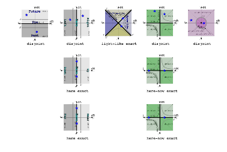

```python
E1 = QH([0, 0, 0, 0])
E2 = QH([1,1,0,0])
E3 = QH([2,0, 0, 0])
eq_E12 = EQ(E1, E2)
eq_E13 = EQ(E1, E3)
eq_E23 = EQ(E2, E3)
print(eq_E12)
eq_E12.visualize()
```

```
The equivalence classes for this pair of events are as follows...
q1: (0, 0, 0, 0) Q
q2: (2, 0, 0, 0) Q
q1_squared: (0, 0, 0, 0) Q
q2_squared: (4, 0, 0, 0) Q
q1_norm_squared -1: (-1, 0, 0, 0) Q
q2_norm_squared -1: (3, 0, 0, 0) Q
                time: disjoint
             space-1: here_exact
             space-2: here_exact
             space-3: here_exact
           causality: disjoint
  space-times-time-1: here-now_exact
  space-times-time-2: here-now_exact
  space-times-time-3: here-now_exact
norm_squared_of_unity: disjoint
```

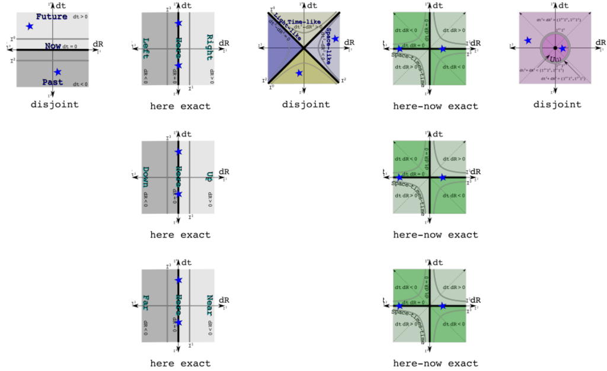

```python
print(eq_E13)
eq_E13.visualize()
```

```
The equivalence classes for this pair of events are as follows...
q1: (1, 1, 0, 0) Q
q2: (2, 0, 0, 0) Q
q1_squared: (0, 2, 0, 0) Q
q2_squared: (4, 0, 0, 0) Q
q1_norm_squared -1: (1, 0, 0, 0) Q
q2_norm_squared -1: (3, 0, 0, 0) Q
                time: future
             space-1: disjoint
             space-2: here_exact
             space-3: here_exact
           causality: disjoint
  space-times-time-1: disjoint
  space-times-time-2: here-now_exact
  space-times-time-3: here-now_exact
norm_squared_of_unity: greater_than_unity
```

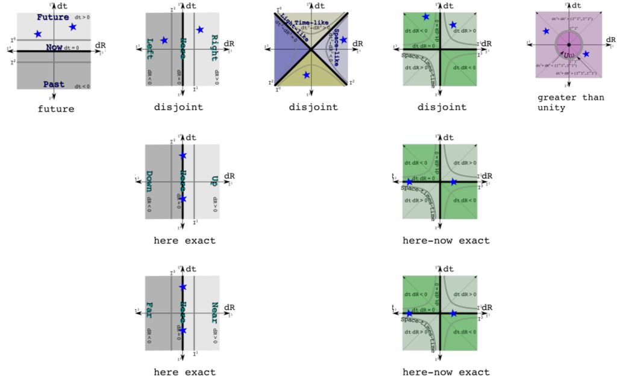

```python
print(eq_E23)
eq_E23.visualize()
```

```python
q12 = Q8([1,2,0,0,0,0,0,0])
q12inv = q12.invert()
q1221 = q12.product(q12inv)
q1221n2 = q1221.norm_squared()
print(q12)
print(q12inv)
print(q1221)
print(q1221n2)
print(q1221n2.reduce())
```

```
((1, 2), (0, 0), (0, 0), (0, 0)) Q
((1.0, 2.0), (0.0, 0.0), (0.0, 0.0), (0.0, 0.0)) Q.^-1
((5.0, 4.0), (0.0, 0.0), (0.0, 0.0), (0.0, 0.0)) QxQ.^-1
((41.0, 40.0), (0, 0), (0, 0), (0, 0)) QxQ.^-1.norm_squared
((1.0, 0), (0, 0), (0, 0), (0, 0)) QxQ.^-1.norm_squared.reduce
```

```python
Q12 = QH([1, 2,0, 0, 0, 0, 0,0])
Q12inv = Q12.invert()
Q1221 = Q12.product(Q12inv)
print(Q1221)
```

```
(1.0, 0.0, 0.0, 0.0) QxQ.^-1
```

```python
q12 = Q8([1,2,0,0,0,0,0,0])
qcrazy = Q8([1,12,2,3,13,2,7,5])
print(q12.product(q12.invert()).reduce())
print(q12.invert())
print(qcrazy.product(qcrazy.invert()).reduce())
```

```
((1.0, 0), (0.0, 0.0), (0.0, 0.0), (0.0, 0.0)) QxQ.^-1.reduce
((1.0, 2.0), (0.0, 0.0), (0.0, 0.0), (0.0, 0.0)) Q.^-1
((1.0, 0), (0, 0), (0, 0), (0, 0)) QxQ.^-1.reduce
```

```python
print(q12)
print(q12.invert())
print(q12.product(q12.invert()))
print(q12.product(q12.invert()).norm_squared())
```

```
((1, 2), (0, 0), (0, 0), (0, 0)) Q
((1.0, 2.0), (0.0, 0.0), (0.0, 0.0), (0.0, 0.0)) Q.^-1
((5.0, 4.0), (0.0, 0.0), (0.0, 0.0), (0.0, 0.0)) QxQ.^-1
((41.0, 40.0), (0, 0), (0, 0), (0, 0)) QxQ.^-1.norm_squared
```

```python
print(qcrazy.product(qcrazy.invert()).reduce())
```

```
((1.0, 0), (0, 0), (0, 0), (0, 0)) QxQ.^-1.reduce
```

```python
print(qcrazy.norm_squared())
print(qcrazy.invert().norm_squared())
print(q12.norm_squared().product(qcrazy.invert().norm_squared()))
```

```
((405, 158), (0, 0), (0, 0), (0, 0)) Q.norm_squared
((0.006638364831418315, 0.0025897818354668986), (0, 0), (0, 0), (0, 0)) Q.^-1.norm_squared
((0.04355095149895917, 0.039502368503007756), (0.0, 0.0), (0.0, 0.0), (0.0, 0.0)) Q.norm_squaredxQ.^-1.norm_squared
```

```python
d12 = Doublet([1,2])
d12.Z2_product(d12)
print("{} {}".format(d12.p, d12.n))
```

```
1 2
```

```python
qa = Q8([1,2,3,4])
qi = Q8([0,1,0,0])
print(qi.product(qa).product(qi).conj())
```

```
((0, 1), (2, 0), (0, 3), (0, 4)) QxQxQ.*
```

```python
q1n=Q8([-1,0,0,0])
print(qa.conj().conj(1).conj(2).product(q1n))
print(qa.conj().conj(2).conj(1).product(q1n))
print(qa.conj(2).conj(1).conj().product(q1n))
```

```
((0, 1), (0, 2), (0, 3), (4, 0)) Q.*.*1.*2xQ
((0, 1), (0, 2), (0, 3), (4, 0)) Q.*.*2.*1xQ
((0, 1), (0, 2), (0, 3), (4, 0)) Q.*2.*1.*xQ
```

```python
qa = QH([1,2,3,4])
print(qa.vahlen_conj())
print(qa.vahlen_conj("'"))
print(qa.vahlen_conj("*"))
```

```
(1, -2, -3, -4) Q.vc*-
(1, -2, -3, 4) Q.vc*'
(1, 2, 3, -4) Q.vc*
```

```python
print(qa)
print(qa.product(QH([0, 0, 1, 0])))
print(QH([0, 0, 1, 0]).product(qa.product(QH([0, 0, -1, 0]))))
print(qa.square().norm_squared_of_vector())
print(QH([0, 0, 1, 0]).product(qa.product(QH([0, 0, -1, 0]))).square().norm_squared_of_vector())
print(qa.norm_squared())
print(QH([0, 0, 1, 0]).product(qa.product(QH([0, 0, -1, 0]))).norm_squared())
```

```
(1, 2, 3, 4) Q
(-3, -4, 1, 2) QxQ
(1, -2, 3, -4) QxQxQ
(116, 0, 0, 0) Q.sq.norm_squaredV
(116, 0, 0, 0) QxQxQ.sq.norm_squaredV
(30, 0, 0, 0) Q.norm_squared
(30, 0, 0, 0) QxQxQ.norm_squared
```